# Stats 20, 20s – Homework 1

Takao Oba – 205615894

10/5/2021

## Question 1.

### (a)

“**Sometimes you have to make the hardest climb to see the most beautiful sunrise.** I read that once on an old lady’s decorative pillow, but it is really how I feel today. I’ve climbed a very weird and rocky mountain, and it was a pain in the ass, and my legs are tired, and I’m starving. But *the sun in rising over a sea of love and waffles and possibility.* So *I’m just gonna relax and take a deep breath and enjoy this view for as long as I possibly can.*” - Leslie Knope (from *Parks and Recreation*)

### (b)

| Homework | Midterm | Final Exam | Final Project |
| --- | --- | --- | --- |
| 18% | 30% | 40% | 12% |

### (c)

- 2020
  - Fall
    - English 1BH
    - Comp Sci 1
    - Art 208H
    - Anth 2
    - Math 270
  - Winter
    - Econ 1
    - English 1CH
- 2021
  - Spring
    - Bus 2
    - Coms 100
    - Math 150H
    - Soc 101H
  - Fall
    - Stats 20
    - Stats 100A
    - Life Science 15

### (d)

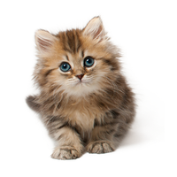

Sample kitten from: https://freepngimg.com/animals/kitten

## Question 2:

### (a)

Both of these videos explains to us the importance of providing clear and specific instructions. In the first video, the father does what is explicitly stated in his childrens’ instructions to make a peanut butter jelly sandwich. In this class, I am in the same position as Johnna and Evan and the R console is the father. The instructions that I provide will be in the form of coding and since R will do exactly what I tell it to do just like the father, without the correct wording and a clear explanation, the result will not be as I intend it to be. Like the father, R does not like ambiguity. Similarly in the second video, I am in the same position as the lady explaining the recipe. Overall, her instructions are very unclear and the man does not know what to do and eventually quits when he is told to “fold the cheese.” In this class, this is equivalent to an error message that the code provides me because the language is unclear and does not make sense.

### (b)

1. Grab two white breads
2. Place them side by side and spread butter on one of the faces of each bread.
3. Grab a frying pan that can fit the two breads side by side and place it on a stove and let it warm up on medium heat.
4. Cut a butter chunk so that its dimensions are 1/2 inch * 1 inch * 1 inch and place it on the frying pan.
5. When the butter chunk melts to a liquid state, place the two slices of bread on the pan so that the buttered sides are touching the pan.
6. Place two slices of cheddar cheese on each face of the bread that is facing up.
7. Every 30 seconds, check the buttered side of the bread using a spatula.
8. When the buttered side of the bread is beginning to turn into a caramel brown color, use the spatula to carry one of the bread and place it on top of the other bread with the cheese side touching each other.
9. Let the sandwich sit on the frying pan for 30 seconds more each side so that the cheese can melt.
10. Place the made sandwich on a plate and enjoy!

## Question 3:

### (a)

#### (i)

What is $6^8 / 16^5$?

```r
x <- (6^8)
y <- (16^5)
x / y
```

```
## [1] 1.601807
```

The quotient of 6^8 and 16^5 is 1.679616^{6} / 1.048576^{6} = 1.6018066.

#### (ii)

What is $101^{-8/7}$?

```r
x <- 101
y <- (-8/7)
x^y
```

```
## [1] 0.005120908
```

The answer of 101 powered to -8/7 is 101^-1.1428571 = 0.0051209.

#### (iii)

What is the answer to 8 + 3 * $\pi$ - 3 + 4/2 * -1?

```r
x <- 8
y <- 3
z <- pi
a <- 4
b <- 2
c <- -1
x + y * z - y + a / b * c
```

```
## [1] 12.42478
```

The answer to is 8 + 3 * 3.1415927 - 3 + 4 / 2 * -1 = 12.424778.

### (b)

#### (i)

What is log 54 base 2?

```r
x <- 54
y <- 2
log(x, y)
```

```
## [1] 5.754888
```

log 54 base 2 is 5.7548875.

#### (ii)

What is $e^{e^{2^{1/2}}}$?

```r
x <- 2
y <- 1 / 2
exp(exp(x^y))
```

```
## [1] 61.14514
```

$e^{e^{2^{1/2}}}$ is 61.1451398.

#### (iii)

What is $(e^{\pi} + e^{-\pi}) / 2$?

```r
x <- exp(pi)
y <- exp(-pi)
z <- 2
(x + y) / z
```

```
## [1] 11.59195
```

$(e^{\pi} + e^{-\pi}) / 2$ is (23.1406926 + 0.0432139) / 2 = 11.5919533.

### (c)

#### (i)

Find the number of times that 25 goes into 119.

```r
x <- 119
y <- 25
x %/% y
```

```
## [1] 4
```

The number of times 25 goes into 119 is 4.

#### (ii)

Find the remainder after dividing 119 by 25.

```r
x %% y
```

```
## [1] 19
```

The remainder after dividing 119 by 25 is 19.

## Question 4

### (a)

#### (i)

Find the volume of a sphere of radius r = 1. Store the output as an object called vol_1.

```r
vol_1 <- (4 * pi * (1^3)) / 3
vol_1
```

```
## [1] 4.18879
```

The volume of a sphere of radius r = 1 is 4.1887902.

#### (ii)

Find the volume of a sphere of radius r = 4. Store the output as an object called vol_4.

```r
vol_4 <- (4 * pi * (4^3)) / 3
vol_4
```

```
## [1] 268.0826
```

The volume of a sphere of radius r = 4 is 268.0825731.

### (b)

Write a function called vol_sphere() that inputs an argument r and outputs the volume of a sphere of radius r. Set the default of r to be 1.

```r
vol_sphere <- function(r = 1){
  (4 * pi * (r^3)) / 3
}
```

### (c)

#### (i)

Verify that the command vol_sphere() (i.e., calling the function without changing the default argument) computes the same value as vol_1.

```r
vol_sphere()
```

```
## [1] 4.18879
```

vol_sphere() = 4.1887902

vol_1() = 4.1887902

4.1887902 = 4.1887902.

#### (ii)

Use the vol_sphere() function to compute the volume of a sphere of radius 4, and verify that the result is the same value as vol_4.

```r
vol_sphere(4)
```

```
## [1] 268.0826
```

vol_sphere(4) = 268.0825731

vol_4() = 268.0825731

268.0825731 = 268.0825731.

## Question 5

### (a)

Write a function called z_prop() which calculates the z-statistic given the following values/arguments:

x: the number of successes

n: the number of trials

p0: the hypothesized population proportion

```r
z_prop <- function(x, n, p0){
  p <- x / n
  (p - p0) / sqrt( (p0 * (1-p0) ) / n)
}
```

p hat is related to the input arguments because it is the sample proportion. Although they are both expressing proportion, p0 is different from p hat because p0 is the hypothesized population proportion and p hat is calculated from the sample.

### (b)

```r
z_prop(10, 13, 0.6)
```

```
## [1] 1.245505
```

Using the z_prop() function from part (a), the z-statistic for this sample is 1.2455047.

### (c)

The preference of waffles over pancakes in the sample proportion of the residents in the city of Pawnee, Indiana was 1.246 standard deviations greater than the population proportion.

### (d)

```r
z_prop(30, 39, 0.6)
```

```
## [1] 2.157277
```

Using the z_prop() function from part (a), the z-statistic for this sample is 2.1572775.

The z-statistic is 2.1572775 with this sample, compared to the z-statistic of 1.2455047 in part b. The z-statistic changed although 10/13 = 30/39. This is because the equation to solve the z-statistic includes the sample size or “n” which means that the z-statistic will change if the sample size is altered. In this case, the sample size grew from 13 to 39 although the sample proportion was the same, which affected the z-statistic to change.

## Question 6

### (a)

```r
lease_calc <- function(msrp, price,
                       down, n = 36, res = 0.60,
                       mf = 0.001, tax = 0.095){
  cap_cost <- price - down
  res_val <- msrp * res
  depreciation <- (cap_cost - res_val) / n
  fin_charge <- (cap_cost + res_val) * mf
  sub_total <- depreciation + fin_charge
  total <- sub_total * 1.095
  total
}
```

### (b)

```r
lease_calc(31495, 29895, 2500, 36, 0.52, 0.0016, 0.095)
```

```
## [1] 411.8079
```

Using the lease_calc() function from (a), the monthly lease payment on a car with an MSRP of 31,495 dollars sold for 29,895 dollars, with a 2,500 dollars down payment, over 36 months, with a residual percentage of 52%, at a money factor of 0.0016, in Los Angeles where the local sales tax is 9.5% is 411.8079115.

## Question 7

### (a)

The minimum number of coins required is 5. This will break down to one quarter, two dimes, and two pennies (25 + (2 * 10) + (2 *1)).

### (b)

We would want to use as many big coins that we can. This is because we are trying to use the least amount of coins possible and one big coin is equivalent to multiple small coins. If we are given a number, we would divide this number with 25 and divide the remainder by 10, divide this remainder by 5, and divide the final remainder by 1. This logic will be able to break down all positive integers. For example, if we wanted to break down 121, we would first do 121 / 25 = 4 remainder 21. Then, using the 21, we would do 21 / 10 = 2 remainder 1. Then, using the remainder 1, we would do 1 / 5 = 0 remainder 1. Finally, we would do 1 / 1 = 1. The least amount of coins possible would be 4 quarters, 2 dimes, and 1 pennies so in total 7 coins.

### (c)

```r
get_minimum_coins <- function (cents) {
  quarter <- cents %/% 25
  dime <- (cents %% 25) %/% 10
  nickel <- ((cents %% 25) %% 10) %/% 5
  penny <- (((cents %% 25) %% 10) %% 5) %/% 1
  total <- quarter + dime + nickel + penny
  total
}
```

### (d)

#### (i)

```r
get_minimum_coins (31)
```

```
## [1] 3
```

The minimum coins needed for 31 cents is 3.

#### (ii)

```r
get_minimum_coins (48)
```

```
## [1] 6
```

The minimum coins needed for 48 cents is 6.

#### (iii)

```r
get_minimum_coins (139)
```

```
## [1] 10
```

The minimum coins needed for 139 cents is 10.

#### (e)

When determining the number of cents that requires the most coins, I looked for 1. numbers that end in 4 or 9 because these two require at least 4 pennies, and 2. numbers that are closer to 100 because in general, a greater number requires more coins compared to way smaller numbers. 94 requires 9 coins (94 = (3 * 25) + (1 * 10) + (1 * 5) + (4 * 1)) as well as 99 (99 = (3 * 25) + (2 * 10) + (4 * 1)).

```r
get_minimum_coins (94)
```

```
## [1] 9
```

```r
get_minimum_coins (99)
```

```
## [1] 9
```

The minimum coins needed for 94 cents is 9 and the minimum coins needed for 99 cents is 9.

## Question 8

### (a)

Why does the command exp1() give a different answer than exp2()?

In exp1(), there is no set default value, so the program inputs the value of 3 for that was declared in the global environment. On the other hand in exp2(), there is a default value of x = 2. Thus, exp1() will calculate 3^4, which is 81, and exp2() will calculate 2^4, which is 16.

### (b)

Why does the command exp_y() not throw an error? Explain in detail what is happening.

The command exp_y() does not throw an error. This is because when calling the function, the function outputs the entire inner function. In our past examples that we did in class, the outputs were a numeric value of characters, but in this case, exp_y() does not output a numeric value and outputs a function. This is not an error because a function returns an object and in this example of nested functions, the inner function is treated as an object and is outputted.

### (c)

```r
x <- 3
y <- 4
exp_y <- function(x) {
  function(y) {
    x^y
  }
}

exp_y(15)(3)
```

```
## [1] 3375
```

The third power of fifteen is 3375.